# Homework 8-Categorical Data Analysis Model Selection

Jahwanza Knight

2026-10-07

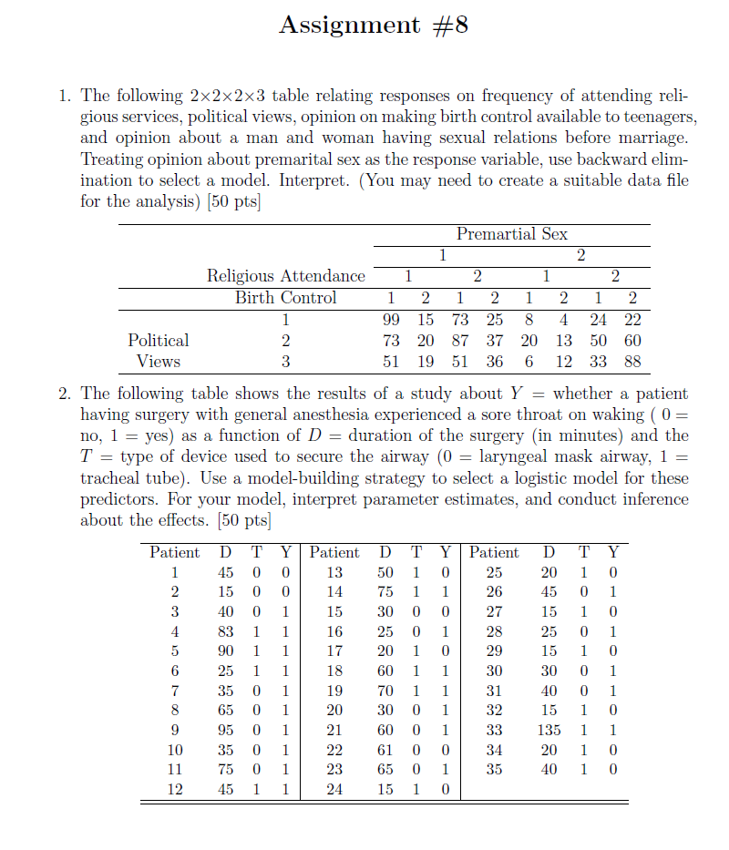

# Problem 1

The model that was chosen from the backwards stepwise selection is the model that has the lowest AIC = 67.84 which is actually the model with only the main effects.

I compared the models using a chi-squared test to determine if they are statistically different. The P-value for the test = 0.56 > 0.05 and suggests that the interaction model does not provide a statistically significant better fit.

```r
#dataframe
yes <-c(99,15,73,25,73,20,87,37,51,19,51,36)
no <-c(8,4,24,22,20,13,50,60,6,12,33,88)
attendance <-rep(c(1,1,2,2),3)
birth_control <-rep(c(1,2),6)
views <-factor(c(rep(1,4),rep(2,4),rep(3,4)))
data <-data.frame(r_attendence=attendance,
                  bc=birth_control, views=views, yes=yes,
                  no=no)
options(contrasts = c("contr.SAS", "contr.poly"))

#main effects model
model_main <- glm(cbind(yes,no) ~ r_attendence+bc+views, family = binomial, data = data)
summary(model_main)
```

```
##
## Call:
## glm(formula = cbind(yes, no) ~ r_attendence + bc + views, family = binomial,
##     data = data)
##
## Coefficients:
##              Estimate Std. Error z value Pr(>|z|)
## (Intercept)   3.86750    0.38966   9.925  < 2e-16 ***
## r_attendence -1.14888    0.16992  -6.761 1.37e-11 ***
## bc           -1.14872    0.15312  -7.502 6.29e-14 ***
## views1        0.80539    0.20353   3.957 7.59e-05 ***
## views2        0.07736    0.17292   0.447    0.655
## ---
## Signif. codes:  0 '***' 0.001 '**' 0.01 '*' 0.05 '.' 0.1 ' ' 1
##
## (Dispersion parameter for binomial family taken to be 1)
##
##     Null deviance: 176.068  on 11  degrees of freedom
## Residual deviance:   5.787  on  7  degrees of freedom
## AIC: 67.841
##
## Number of Fisher Scoring iterations: 4
```

```r
##saturated model
mod.full<- glm(cbind(yes,no) ~ r_attendence*bc*views, family = binomial, data = data)

##
#null model test
lrt <-mod.full$null.deviance -mod.full$deviance
lrt.df<-mod.full$df.null -mod.full$df.residual
round(c (lrt=lrt,df=lrt.df, p=pchisq(lrt,lrt.df,lower.tail = F)),4)
```

```
##      lrt       df        p
## 176.0676  11.0000   0.0000
```

```r
##ODDS RATIO
exp(coef(model_main))
```

```
##  (Intercept) r_attendence           bc       views1       views2
##   47.8228610    0.3169926    0.3170423    2.2375632    1.0804279
```

```r
step_model<-step(mod.full, direction = "backward")
```

```
## Start:  AIC=76.05
## cbind(yes, no) ~ r_attendence * bc * views
##
##                         Df Deviance    AIC
## - r_attendence:bc:views  2  0.45051 72.505
## <none>                      0.00000 76.054
##
## Step:  AIC=72.5
## cbind(yes, no) ~ r_attendence + bc + views + r_attendence:bc +
##     r_attendence:views + bc:views
##
##                      Df Deviance    AIC
## - bc:views            2   2.0418 70.096
## - r_attendence:bc     1   0.4910 70.545
## - r_attendence:views  2   4.0308 72.085
## <none>                    0.4505 72.505
##
## Step:  AIC=70.1
## cbind(yes, no) ~ r_attendence + bc + views + r_attendence:bc +
##     r_attendence:views
##
##                      Df Deviance    AIC
## - r_attendence:bc     1   2.0615 68.116
## - r_attendence:views  2   5.7866 69.841
## <none>                    2.0418 70.096
##
## Step:  AIC=68.12
## cbind(yes, no) ~ r_attendence + bc + views + r_attendence:views
##
##                      Df Deviance     AIC
## - r_attendence:views  2    5.787  67.841
## <none>                     2.062  68.116
## - bc                  1   58.572 122.626
##
## Step:  AIC=67.84
## cbind(yes, no) ~ r_attendence + bc + views
##
##                Df Deviance     AIC
## <none>               5.787  67.841
## - views         2   24.897  82.951
## - r_attendence  1   55.154 115.209
## - bc            1   63.095 123.149
```

```r
## comparing models
anova(step_model, mod.full, test="Chisq")
```

```
## Analysis of Deviance Table
##
## Model 1: cbind(yes, no) ~ r_attendence + bc + views
## Model 2: cbind(yes, no) ~ r_attendence * bc * views
##   Resid. Df Resid. Dev Df Deviance Pr(>Chi)
## 1         7      5.787
## 2         0      0.000  7    5.787   0.5648
```

# Problem 2

The main effects model provides an AIC=36.138 compared to the AIC of the saturated model = 36.321. The effect of T on the response variable is not statistically significant but the predictor D is statistically significant.

Using our estimates of the main model T=1, using a tracheal tube decreases our log odds of having a sore throat by -1.6. and for every minute increase in duration we have an increase log odds by 0.0687, regardless of device type. Also , the LRT test we observe a p-value << 0.05 and as such we can reject the hypothesis that the null model and the current model are statistically the same.

```r
library(readr)

tab8_2 <- read_csv("D:/Documents/BioStatistics/PHST-684/tab8.2.csv")

tab8_2$T<- as.factor(tab8_2$T)
tab8_2$Y<- as.factor(tab8_2$Y)

options(contrasts = c("contr.treatment", "contr.poly"))

model_main <- glm(Y ~ D + T, family = binomial,
                  data = tab8_2)
summary(model_main)
```

```
##
## Call:
## glm(formula = Y ~ D + T, family = binomial, data = tab8_2)
##
## Coefficients:
##             Estimate Std. Error z value Pr(>|z|)
## (Intercept) -1.41734    1.09457  -1.295  0.19536
## D            0.06868    0.02641   2.600  0.00931 **
## T1          -1.65895    0.92285  -1.798  0.07224 .
## ---
## Signif. codes:  0 '***' 0.001 '**' 0.01 '*' 0.05 '.' 0.1 ' ' 1
##
## (Dispersion parameter for binomial family taken to be 1)
##
##     Null deviance: 46.180  on 34  degrees of freedom
## Residual deviance: 30.138  on 32  degrees of freedom
## AIC: 36.138
##
## Number of Fisher Scoring iterations: 5
```

```r
options(contrasts = c("contr.treatment", "contr.poly"))

#sat_model
mod.full <-glm(Y ~T*D, data=tab8_2, family=binomial)
summary(mod.full)
```

```
##
## Call:
## glm(formula = Y ~ T * D, family = binomial, data = tab8_2)
##
## Coefficients:
##             Estimate Std. Error z value Pr(>|z|)
## (Intercept)  0.04979    1.46940   0.034   0.9730
## T1          -4.47224    2.46707  -1.813   0.0699 .
## D            0.02848    0.03429   0.831   0.4062
## T1:D         0.07460    0.05777   1.291   0.1966
## ---
## Signif. codes:  0 '***' 0.001 '**' 0.01 '*' 0.05 '.' 0.1 ' ' 1
##
## (Dispersion parameter for binomial family taken to be 1)
##
##     Null deviance: 46.180  on 34  degrees of freedom
## Residual deviance: 28.321  on 31  degrees of freedom
## AIC: 36.321
##
## Number of Fisher Scoring iterations: 6
```

```r
#backwards step
mod.full_step<-step(mod.full, direction = "backward")
```

```
## Start:  AIC=36.32
## Y ~ T * D
##
##        Df Deviance    AIC
## - T:D   1   30.138 36.138
## <none>      28.321 36.321
##
## Step:  AIC=36.14
## Y ~ T + D
##
##        Df Deviance    AIC
## <none>      30.138 36.138
## - T     1   33.651 37.651
## - D     1   42.578 46.578
```

```r
anova(mod.full_step,mod.full,test = "Chisq")
```

```
## Analysis of Deviance Table
##
## Model 1: Y ~ T + D
## Model 2: Y ~ T * D
##   Resid. Df Resid. Dev Df Deviance Pr(>Chi)
## 1        32     30.138
## 2        31     28.321  1   1.8169   0.1777
```

```r
#null model test
lrt <- mod.full$null.deviance - mod.full$deviance
lrt.df<- mod.full$df.null - mod.full$df.residual
round(c (lrt=lrt,df=lrt.df, p=pchisq(lrt,lrt.df,lower.tail = F)),4)
```

```
##     lrt      df       p
## 17.8588  3.0000  0.0005
```

```r
exp(coef(mod.full_step))
```

```
## (Intercept)          T1           D
##   0.2423575   0.1903389   1.0710910
```